# Course2 R Programming - Assignment 3

Haoyi Wei

2022-12-21

Programming Assignment 3

The data for this assignment come from the Hospital Compare web site (http://hospitalcompare.hhs.gov) run by the U.S. Department of Health and Human Services. The purpose of the web site is to provide data and information about the quality of care at over 4,000 Medicare-certi ed hospitals in the U.S. This dataset essentially covers all major U.S. hospitals. This dataset is used for a variety of purposes, including determining whether hospitals should be fined for not providing high quality care to patients.

```r
# set the working directory
setwd("~/Documents/GitHub/Coursera_Data_Science_Certificate/2_R Programming/Code")
# packages
library(dplyr)
```

# 1 Plot the 30-day mortality rates for heart attack

```r
# Read the outome data into R via the read.csv function.
outcome <-read.csv("./hospital/outcome-of-care-measures.csv")
```

```r
# look at the first few rows
head(outcome)
```

```r
# Check the number of column or row
ncol(outcome)
```

```
## [1] 46
```

```r
nrow(outcome)
```

```
## [1] 4706
```

```r
# names of each column
names(outcome)
```

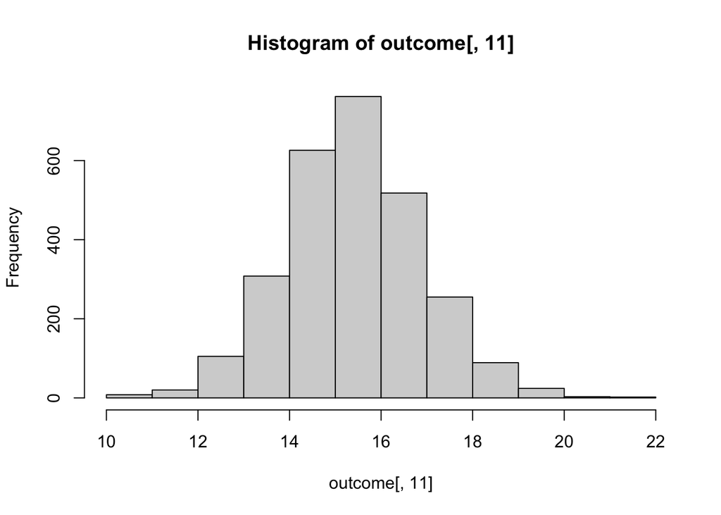

```r
# To make a simple histogram of the 30-day death rates from heart attack (column 11 in the outcome dataset), run

outcome[, 11] <- as.numeric(outcome[, 11])
## You may get a warning about NAs being introduced; that is okay

hist(outcome[, 11])
```

# 2 Finding the best hospital in a state

Write a function called best that take two arguments: the 2-character abbreviated name of a state and an outcome name. The function reads the outcome-of-care-measures.csv and returns a character vector with the name of the hospital that has the best (i.e. lowest) 30-day mortality for the specied outcome in that state. The hospital name is the name provided in the Hospital.Name variable. The outcomes can be one of heart attack”, heart failure”, or pneumonia”. Hospitals that do not have data on a particular outcome should be excluded from the set of hospitals when deciding the rankings.

```r
best <- function(st, out) {
  ## Read outcome data
        ## clean the dataset to restricted to interested variables and convert character to numeric.
          outcome1 <- outcome %>%
            select(Provider.Number,Hospital.Name,State, starts_with("Hospital.30.Day.Death..Mortality..Rates.from.")) %>%
            mutate(across(starts_with("Hospital.30.Day.Death..Mortality..Rates.from."), ~as.numeric(.x))) %>%
            rename_with(~tolower(gsub("Hospital.30.Day.Death..Mortality..Rates.from.","",.x))) %>% # change all variables to lower case and rename some variables.
            rename_with(~gsub("\\."," ",.x))

  ## Check that state and outcome are valid
            if(!st %in% outcome1[,"state"]){
              stop('invalid state')
            }

            if(!out %in% c("heart attack","heart failure","pneumonia")){
              stop('invalid outcome')
            }

  ## Return hospital name in that state with lowest 30-day death

           ## get only the hospitals in chosen state
          outcome2 <- outcome1[outcome1[,"state"]==st,]

          ## generate a variable equal to the minium
          outcome2[,"low"] <- min(outcome2[,out],na.rm=T)

          ## only choose the row with lowest outcome.
          outcome3 <- outcome2[outcome2[,"low"]==outcome2[,out],]

          ## sort the dataset/handling ties
          outcome4 <- outcome3[order(outcome3[,2],decreasing=T),]

          ## get the name of the hospital
          name <-outcome4[1,2]
          name
}
```

```r
best("TX","heart attack")

best("TX", "heart failure")

best("MD", "pneumonia")

best("BB", "heart attack")

best("NY", "hert attack")
```

[output not shown]

# 3 Ranking hospitals by outcome in a state

Write a function called rankhospital that takes three arguments: the 2-character abbreviated name of a state (state), an outcome (outcome), and the ranking of a hospital in that state for that outcome (num).The function reads the outcome-of-care-measures.csv le and returns a character vector with the name of the hospital that has the ranking specified by the num argument. For example, the call

‘rankhospital(“MD”, “heart failure”, 5)’

```r
rankhospital <- function(st, out, num= `best'`) {
  ## Read outcome data
  ## clean the dataset to restricted to interested variables and convert character to numeric.
          outcome1 <- outcome %>%
            select(Provider.Number,Hospital.Name,State, starts_with("Hospital.30.Day.Death..Mortality..Rates.from.")) %>%
            mutate(across(starts_with("Hospital.30.Day.Death..Mortality..Rates.from."), ~as.numeric(.x))) %>%
            rename_with(~tolower(gsub("Hospital.30.Day.Death..Mortality..Rates.from.","",.x))) %>% # change all variables to lower case and rename some variables.
            rename_with(~gsub("\\."," ",.x))

  ## Check that state and outcome are valid
            if(!st %in% outcome1[,"state"]){
              stop('invalid state')
            }

            if(!out %in% c("heart attack","heart failure","pneumonia")){
              stop('invalid outcome')
            }

  ## Return hospital name in that state with the given rank

          ## get only the hospitals in chosen state
          outcome2 <- outcome1[outcome1[,"state"]==st & !is.na(outcome1[,out]),]

          ## conert num argument to valid rank
          if (num=="best"){
            num <-1
          }

          if (num=="worst"){
            num <-nrow(outcome2)
          }

          ## order by outcome rate
          outcome3 <- outcome2[order(outcome2[,out],outcome2[,2]),]

          ## Get the name of hospital

          outcome3[num,2]

}


rankhospital("MD","heart attack", "worst")
```

```
## [1] "HARFORD MEMORIAL HOSPITAL"
```

```r
rankhospital("MD","heart attack", "50000")
```

```
## [1] NA
```

```r
# 4 Ranking hospitals in all states ----

rankall <- function(out, num = "best") {
  ## Read outcome data
  ## clean the dataset to restricted to interested variables and convert character to numeric.
            outcome1 <- outcome %>%
              select(Provider.Number,Hospital.Name,State, starts_with("Hospital.30.Day.Death..Mortality..Rates.from.")) %>%
              mutate(across(starts_with("Hospital.30.Day.Death..Mortality..Rates.from."), ~as.numeric(.x))) %>%
              rename_with(~tolower(gsub("Hospital.30.Day.Death..Mortality..Rates.from.","",.x))) %>% # change all variables to lower case and rename some variables.
              rename_with(~gsub("\\."," ",.x))

  ## Check that state and outcome are valid
              if(!out %in% c("heart attack","heart failure","pneumonia")){
                stop('invalid outcome')
              }

  ## For each state, find the hospital of the given rank

            ## Return hospital name in that state with the given rank

            ## get only the hospitals with nonmissing outcome
            outcome2 <- outcome1[!is.na(outcome1[,out]),]

            ## conert num argument to valid rank
            if (num=="best"){
              num <-1
            }

            if (num=="worst"){
              num <-10000
            }

            # "out" may not be easily recognized by dplyr. becasue it comes with "".
            outcome3 <- outcome2
            outcome3[,"out_new"] <- outcome2[,out]

            outcome4 <- outcome3 %>%
              select(`hospital name`,state,out_new) %>%
              arrange(state,out_new,`hospital name`) %>%
              group_by(state) %>%
              mutate(position=1:n()) %>%
              mutate(pp=replace(position, position==n(), 10000)) %>%
              ungroup() %>%
              filter(pp==num) %>%
              mutate(hospital=`hospital name`) %>%
              select(hospital,state)

            # the outcome 4 do not have state contains missing value
            outcome5 <- outcome3 %>%
              distinct(state)

            outcome6 <- left_join(outcome5, outcome4, by="state") %>%
              relocate(hospital,state) %>%
              arrange(state)

            outcome6
}
```

```r
head(rankall("heart attack",20),10)

tail(rankall("heart failure"), 10)

tail(rankall("pneumonia", "worst"), 3)
```

[output not shown]

# Quiz

```r
best("SC", "heart attack")
```

```
## [1] "MUSC MEDICAL CENTER"
```

```r
best("NY", "pneumonia")
```

```
## [1] "MAIMONIDES MEDICAL CENTER"
```

```r
best("AK", "pneumonia")
```

```
## [1] "YUKON KUSKOKWIM DELTA REG HOSPITAL"
```

```r
rankhospital("NC", "heart attack", "worst")
```

```
## [1] "WAYNE MEMORIAL HOSPITAL"
```

```r
rankhospital("WA", "heart attack", 7)
```

```
## [1] "YAKIMA VALLEY MEMORIAL HOSPITAL"
```

```r
rankhospital("TX", "pneumonia", 10)
```

```
## [1] "SETON SMITHVILLE REGIONAL HOSPITAL"
```

```r
rankhospital("NY", "heart attack", 7)
```

```
## [1] "BELLEVUE HOSPITAL CENTER"
```

```r
r <- rankall("heart attack", 4)
as.character(subset(r, state == "HI")$hospital)
```

```
## [1] "CASTLE MEDICAL CENTER"
```

```r
r <- rankall("pneumonia", "worst")
as.character(subset(r, state == "NJ")$hospital)
```

```
## [1] "BERGEN REGIONAL MEDICAL CENTER"
```

```r
r <- rankall("heart failure", 10)
as.character(subset(r, state == "NV")$hospital)
```

```
## [1] "RENOWN SOUTH MEADOWS MEDICAL CENTER"
```